# Network Analysis for Legal Research

```python
import pandas as pd
import networkx as nx
import matplotlib.pyplot as plt
from src.helper import load_graph_from_json, draw_spring
import karateclub
import numpy as np
from sklearn.cluster import KMeans
import warnings
from IPython.display import Image
```

```python
warnings.filterwarnings("ignore")
np.random.seed(123)
g_karate = nx.karate_club_graph()
g_kite = nx.krackhardt_kite_graph()
g_gc = load_graph_from_json("data/g_gcextraterritorial_cases.json")
pd.set_option("display.precision",3)
```

## For the whole project see the textbook [here](https://github.com/maastrichtlawtech/legalnetworkanalysis_textbook) (with G.van Dijck and R. Moerland)

## Why network analysis?

- Law involves relational data, for which networks are promising.
- In terms of methods we are behind the times (cfr. economics, psychology, political science).
- Law deals with categorical variables. It is only recently that methods for dealing with categorical variables have become widespread and easy to teach and to use.
- Network Analysis can provide insight in datasets smaller than those typically required by other methods.
- The math involved in network analysis is approachable. A lot more can be learned with just sums and averages, in comparison with linear regression (where OLS already requires higher level math). Add matrix multiplication and one is in ok shape.
- (otoh a relatively high level of python is needed. You need to be comfortable with dictionaries, views and list comprehensions, more so than with Scikit-learn, Pandas or Statsmodels)
- it is very general, see below:

### Jurimetric relations:

- articles related to other articles
- cases citing other cases
- document similarity networks

### Also socio-legal relations

- Connections between actors
- Criminal networks
- Companies sharing a CEO or other high official
- Degree of separation between private sector and public sector in a country.
- Connections between interviewees.

### Legal Reasoning and Argumentation

- Arguments can be seen as forming a network structure.
- And so can value rankings.
- Networks may be used as an evaluation tool.

### Very general

Networks are in the end just one more data type that can be inserted into any machine learning algorithm (with some work)

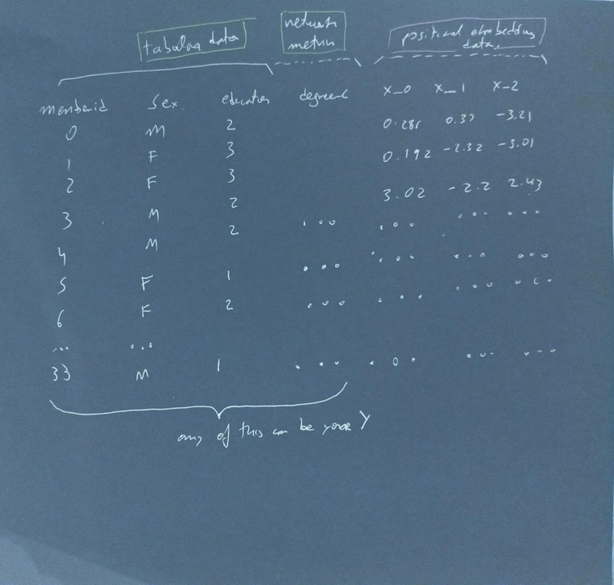

```python
Image(data="img/expanded_karate.jpeg")
```

## Examples

- M. Derlen and J. Lindholm (2014). Goodbye van Gend en Loos, Hello Bosman? Using Network Analysis to Measure the Importance of Individual CJEU Judgments. European Law Journal, 20(5), 667-87
- J. Fowler and S. Leon, ‘The Authority of Supreme Court Precedent’ (2008) 30 Social Networks 16-39
- R. Whalen, A. Lungeanu, L. DeChurch, and N. Contractor (2020). Patent Similarity Data and Innovation Metrics, Journal of Empirical Legal Studies 17(3), 615-639
- Y. Lupu and E. Voeten (2011). Precedent in International Courts: A Network Analysis of Case Citations by the European Court of Human Rights. British Journal of Political Science, 42, 413-49
- E. Lazega, D. Krackhardt (2020). Spreading and Shifting Costs of Lateral Control Among Peers: A Structural Analysis at the Individual Level. Quality & Quantity 34, 153–175
- P. Seidler & R. Adderley (2013). Criminal Network Analysis inside Law Enforcement Agencies: A Data-Mining System Approach under the National Intelligence Model. International Journal of Police Science & Management, 15(4), 323–337

## Datasets

Here we will only use 3 networks

- The Krackhard Kite graph, which is purely abstract, but helps us compare different centrality measures.
- Zachary's karate club graph, which is based on real social research, and will be most useful for trying to show the power of networks to provide predictions in real world scenarios.
- A small network of citations between ECHR Grand Chamber judgements that consider the topic of extraterritorial obligations. This will be mostly to introduce a directed, legal example. However this network is more complicated than the others.

# Terminology

## Nodes

Nodes are the dots of the network, they represent the entities that are related by edges.

## Edges

Edges join nodes together (or not). Every edge represents ONE type of relationship:

- "i is friends with j"
- "i Cites j"
- "i is to this extent w similar or different to j"

Edges can be directed or undirected. A friendship is normally undirected, citations are directed.

Edges can be unweighted and to that extent network analysis is purely qualitative, or they can be weighted and then it has a quantiative dimension.

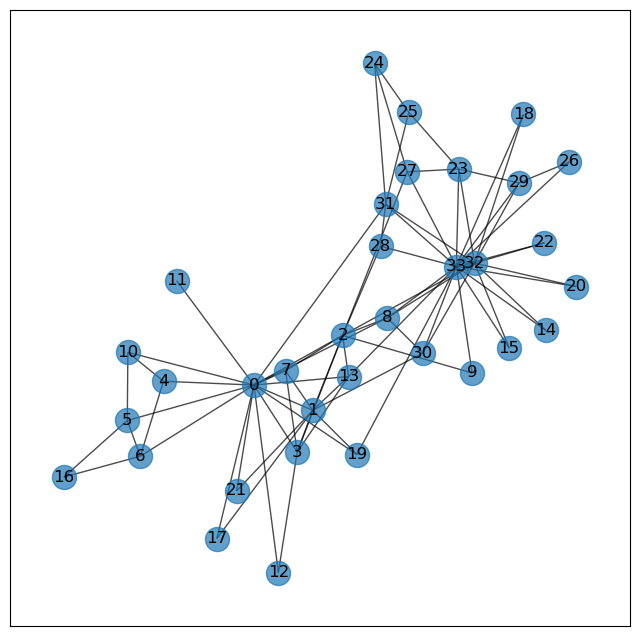

```python
draw_spring(g_karate)
```

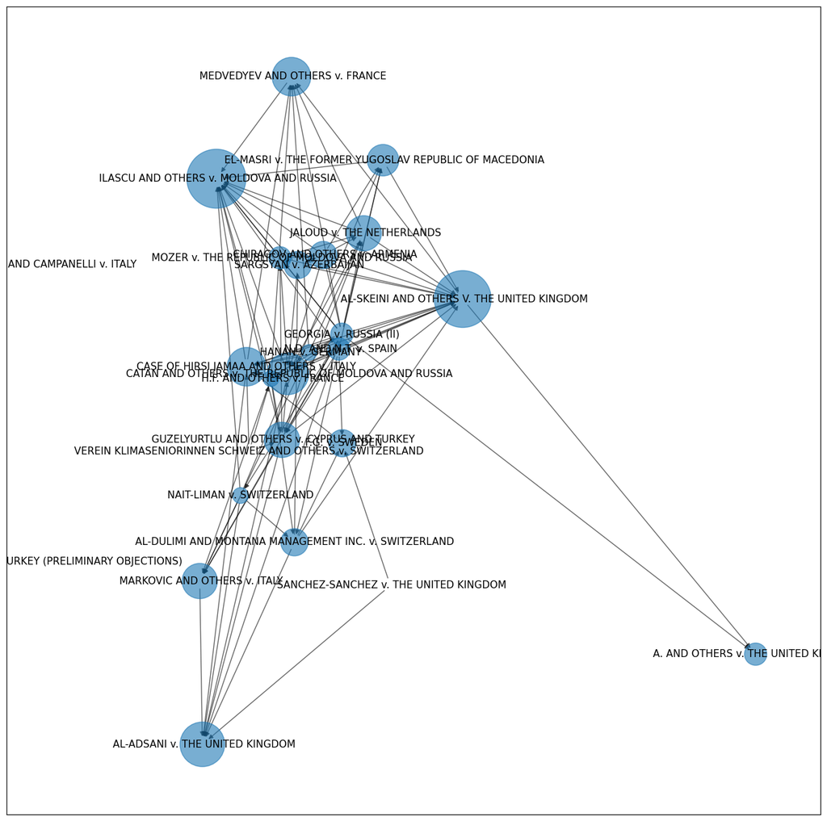

```python
in_degree_gc = list(dict(g_gc.in_degree()).values())
g_gc_labels = dict(g_gc.nodes.data("name"))
plt.figure(figsize=(16,16))
pos = nx.spring_layout(g_gc, seed=42, k=0.5)
nx.draw_networkx_nodes(g_gc, pos=pos, node_size=[x*300 for x in in_degree_gc], alpha=0.6)
nx.draw_networkx_edges(g_gc, pos=pos, alpha=0.6)
nx.draw_networkx_labels(g_gc, pos=pos, labels=g_gc_labels, font_size=11);
```

## Path

A path is a traversal from one node to another. Of greatest interest here are shortest paths. IE. what is the shortest path to get from node 2 to node 8?

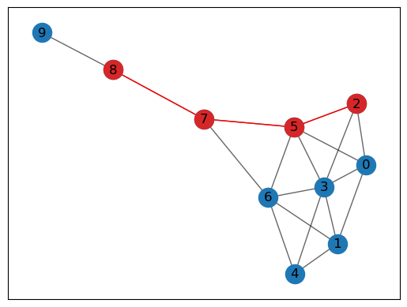

```python
shortest8to2 = nx.shortest_path(g_kite, source=8, target=2)
pos = nx.spring_layout(g_kite, seed=123)
nx.draw_networkx_nodes(g_kite, pos=pos)
nx.draw_networkx_nodes(g_kite, pos=pos, nodelist=shortest8to2, node_color="tab:red")
nx.draw_networkx_edges(g_kite, pos=pos, alpha=0.6)
nx.draw_networkx_edges(g_kite, pos=pos, edgelist=[(8,7),(7,5),(5,2)], edge_color="red", alpha=1)
nx.draw_networkx_labels(g_kite, pos=pos);
```

## Centrality Measures

These record which nodes of the network are more important (more important cases, more important participants of a criminal network, more important interviews),

### Degree Centrality

The easiest measure only records the amount of neighbors a node has, ie. its degree and divides it by n-1 to normalize it to the size of the network (having 5 neighbors in a network of 6 nodes is a big deal, having 5 neighbors in a network of 600 nodes, possibly is not).

$$ \frac{degree(n)}{|N|-1} \mid n \in N $$

> Looking at the kite, node 3 is the clear winner. We can see that just by looking. It has a degree of 6.

```python
draw_spring(g_kite)
```

[output not shown]

> Can we use degree centrality to figure who is the President and Instructor?

```python
results = nx.degree_centrality(g_karate)
resdf = pd.DataFrame({"nodes":results.keys(), "centrality":results.values()})
resdf.sort_values("centrality", ascending=False).head(10)
```

|  | nodes | centrality |
| --- | --- | --- |
| 33 | 33 | 0.515 |
| 0 | 0 | 0.485 |
| 32 | 32 | 0.364 |
| 2 | 2 | 0.303 |
| 1 | 1 | 0.273 |
| 3 | 3 | 0.182 |
| 31 | 31 | 0.182 |
| 23 | 23 | 0.152 |
| 8 | 8 | 0.152 |
| 13 | 13 | 0.152 |

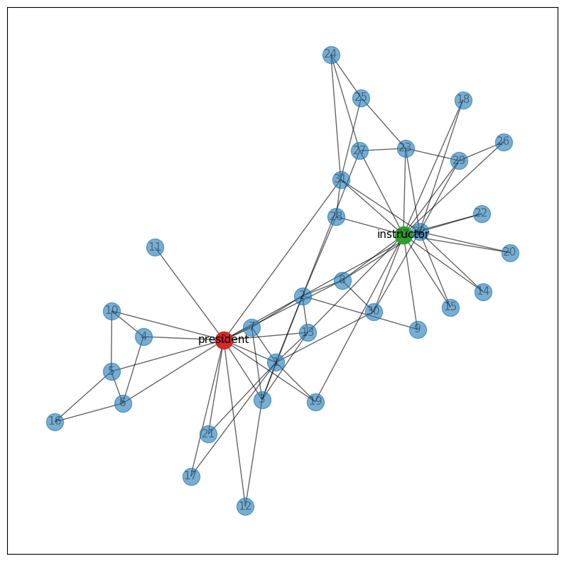

```python
plt.figure(figsize=(10,10))
pos = nx.spring_layout(g_karate, seed=123)
nx.draw_networkx_nodes(g_karate, pos=pos, alpha=0.6)
nx.draw_networkx_nodes(g_karate, pos=pos, node_color="tab:red", nodelist=[0])
nx.draw_networkx_nodes(g_karate, pos=pos, node_color="tab:green", nodelist=[33])
nx.draw_networkx_edges(g_karate, pos=pos, alpha=0.6)
nx.draw_networkx_labels(g_karate, pos=pos, font_size=11, alpha=0.4)
nx.draw_networkx_labels(g_karate, pos=pos, labels={33:"instructor", 0:"president"}, font_size=11);
```

### Closeness Centrality

Closeness centrality expresses the average closeness between a target node $ u $ and the set of all other nodes it can reach $ V $, when taking the shortest path between the node under examination and the reachable nodes (this shortest path is often called the 'geodesic path'). The greater the average closeness of one node to all other nodes using the shortest paths, the more central the node is. Remember here that closeness is the reciprocal of the distance it appears as at inverse average:

$$ \frac{|V|-1}{\sum_{V_1}^{V_n}spath(v,u)} $$

> Remember that 3 was the winning node in degree centrality? Closeness changes things, because it takes into account indirect connections. Nodes 5 and 6 have shorter paths to access nodes 7 8 and 9, so they score higher here than node 3.

```python
draw_spring(g_kite)
```

[output not shown]

```python
results_closeness = nx.closeness_centrality(g_kite)
results_degree = nx.degree_centrality(g_kite)
resdf = pd.DataFrame({"nodes": results_closeness.keys(),
                      "degree":results_degree.values(),
                      "closeness": results_closeness.values()})
resdf.sort_values("closeness",ascending=False)
```

|  | nodes | degree | closeness |
| --- | --- | --- | --- |
| 5 | 5 | 0.556 | 0.643 |
| 6 | 6 | 0.556 | 0.643 |
| 3 | 3 | 0.667 | 0.600 |
| 7 | 7 | 0.333 | 0.600 |
| 0 | 0 | 0.444 | 0.529 |
| 1 | 1 | 0.444 | 0.529 |
| 2 | 2 | 0.333 | 0.500 |
| 4 | 4 | 0.333 | 0.500 |
| 8 | 8 | 0.222 | 0.429 |
| 9 | 9 | 0.111 | 0.310 |

### Betweeness Centrality

Now we will consider as most central not just nodes that have a lot of neighbors, but nodes that are "mediators" (or "brokers") in the network. These nodes are the glue that holds the network together. If they are removed, this can cause severe disruption in the network, possibly disconnecting parts of the network.

$$ \sum_{s,t \in V} \frac{spaths(s, t \mid v)}{spath(s, t)} $$

> Once more looking at the kite, from a betweeness perspective, node 7 becomes the winner because it is the "broker" between 8 and 9 and the rest of the kite. If we remove node 7, the network falls apart.

```python
draw_spring(g_kite)
```

[output not shown]

```python
results_betweeness = nx.betweenness_centrality(g_kite)
resdf['betweeness'] = results_betweeness.values()
resdf.sort_values("betweeness", ascending=False)
```

|  | nodes | degree | closeness | betweeness |
| --- | --- | --- | --- | --- |
| 7 | 7 | 0.333 | 0.600 | 0.389 |
| 5 | 5 | 0.556 | 0.643 | 0.231 |
| 6 | 6 | 0.556 | 0.643 | 0.231 |
| 8 | 8 | 0.222 | 0.429 | 0.222 |
| 3 | 3 | 0.667 | 0.600 | 0.102 |
| 0 | 0 | 0.444 | 0.529 | 0.023 |
| 1 | 1 | 0.444 | 0.529 | 0.023 |
| 2 | 2 | 0.333 | 0.500 | 0.000 |
| 4 | 4 | 0.333 | 0.500 | 0.000 |
| 9 | 9 | 0.111 | 0.310 | 0.000 |

### Pagerank

PageRank is a variant of the Eigenvector centrality which is applicable to directed networks. Like Eigenvector Centrality it considers not only the number of links one receives, but also the popularity of those linking to us. It is also based on the "random walk idea": the Pagerank score corresponds to the likelihood of a user ending up on that page by randomly clicking from link to link.

The math of pagerank is a little bit more complicated, but you can see it in the textbook. The general idea can be explained as repeated updating of a vector that by a matrix representing the network. A sketch below: *(but pagerank does not use the adjacency matrix, nor does HITS, see textbook).*

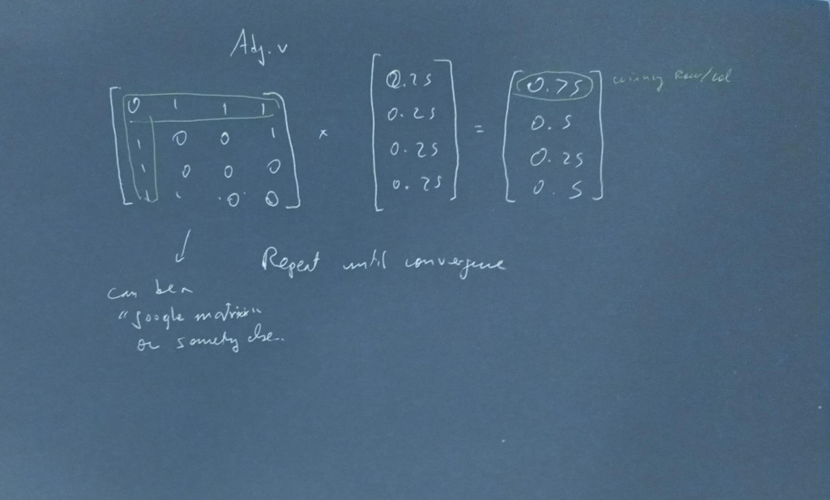

```python
Image(data="img/multiplication.jpeg")
```

```python
results = nx.pagerank(g_gc)
pagerank_scores = np.array(list(results.values()))
pagerank_scores = pagerank_scores/(np.sum(pagerank_scores))

pagerank_scores_multiple = pagerank_scores*30000
```

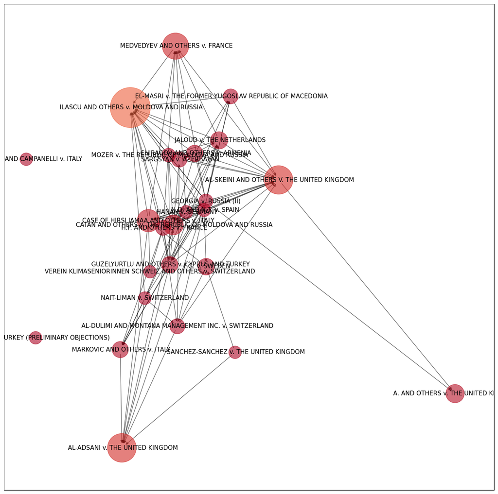

```python
results = nx.pagerank(g_gc)
cmap = plt.get_cmap("RdYlGn")
g_gc_labels = dict(g_gc.nodes.data("name"))
plt.figure(figsize=(16,16))
pos = nx.spring_layout(g_gc, seed=42, k=0.5)
nx.draw_networkx_nodes(g_gc, pos=pos, node_size=[x for x in pagerank_scores_multiple], alpha=0.6, node_color=[cmap(x) for x in pagerank_scores])
nx.draw_networkx_edges(g_gc, pos=pos, alpha=0.6)
nx.draw_networkx_labels(g_gc, pos=pos, labels=g_gc_labels, font_size=11);
```

```python
casenames = dict(g_gc.nodes.data("name")).values()
resdf = pd.DataFrame({"nodes": casenames, "pagerank":results.values()})
resdf.sort_values("pagerank", ascending=False).head(10)
```

|  | nodes | pagerank |
| --- | --- | --- |
| 8 | ILASCU AND OTHERS v. MOLDOVA AND RUSSIA | 0.178 |
| 7 | AL-ADSANI v. THE UNITED KINGDOM | 0.092 |
| 1 | AL-SKEINI AND OTHERS V. THE UNITED KINGDOM | 0.090 |
| 0 | MEDVEDYEV AND OTHERS v. FRANCE | 0.077 |
| 2 | CASE OF HIRSI JAMAA AND OTHERS v. ITALY | 0.056 |
| 11 | CATAN AND OTHERS v. THE REPUBLIC OF MOLDOVA A... | 0.044 |
| 6 | A. AND OTHERS v. THE UNITED KINGDOM | 0.037 |
| 13 | JALOUD v. THE NETHERLANDS | 0.033 |
| 17 | F.G. v. SWEDEN | 0.031 |
| 14 | CHIRAGOV AND OTHERS v. ARMENIA | 0.030 |

### HITS

HITS Is similar to pagerank in using a random walker model, but provides results of both authorities (imoprtant notes) and hubs (nodes that cite important nodes)

```python
results_hits = nx.hits(g_gc, normalized=True)
hubs = results_hits[0].values()
authorities = results_hits[1].values()
```

I find it unsurprising that Georgia v. Russsia is a Hub

```python
resdf['hubs'] = hubs
resdf['authorities'] = authorities
resdf.sort_values("hubs", ascending=False).head(10)
```

|  | nodes | pagerank | hubs | authorities |
| --- | --- | --- | --- | --- |
| 23 | GEORGIA v. RUSSIA (II) | 0.022 | 0.188 | 6.669e-03 |
| 15 | SARGSYAN v. AZERBAIJAN | 0.026 | 0.162 | 3.120e-02 |
| 14 | CHIRAGOV AND OTHERS v. ARMENIA | 0.030 | 0.153 | 1.046e-01 |
| 13 | JALOUD v. THE NETHERLANDS | 0.033 | 0.096 | 8.177e-02 |
| 16 | MOZER v. THE REPUBLIC OF MOLDOVA AND RUSSIA | 0.021 | 0.082 | 1.289e-02 |
| 11 | CATAN AND OTHERS v. THE REPUBLIC OF MOLDOVA A... | 0.044 | 0.052 | 1.387e-01 |
| 9 | GUZELYURTLU AND OTHERS v. CYPRUS AND TURKEY | 0.030 | 0.041 | 5.080e-02 |
| 24 | HANAN v. GERMANY | 0.019 | 0.040 | 2.195e-03 |
| 3 | H.F. AND OTHERS v. FRANCE | 0.025 | 0.039 | 4.959e-04 |
| 10 | N.D. AND N.T. v. SPAIN | 0.020 | 0.028 | 1.277e-02 |

```python
resdf.sort_values("authorities", ascending=False).head(10)
```

|  | nodes | pagerank | hubs | authorities |
| --- | --- | --- | --- | --- |
| 8 | ILASCU AND OTHERS v. MOLDOVA AND RUSSIA | 0.178 | -0.000 | 0.204 |
| 1 | AL-SKEINI AND OTHERS V. THE UNITED KINGDOM | 0.090 | 0.017 | 0.164 |
| 11 | CATAN AND OTHERS v. THE REPUBLIC OF MOLDOVA A... | 0.044 | 0.052 | 0.139 |
| 14 | CHIRAGOV AND OTHERS v. ARMENIA | 0.030 | 0.153 | 0.105 |
| 13 | JALOUD v. THE NETHERLANDS | 0.033 | 0.096 | 0.082 |
| 9 | GUZELYURTLU AND OTHERS v. CYPRUS AND TURKEY | 0.030 | 0.041 | 0.051 |
| 0 | MEDVEDYEV AND OTHERS v. FRANCE | 0.077 | 0.011 | 0.050 |
| 15 | SARGSYAN v. AZERBAIJAN | 0.026 | 0.162 | 0.031 |
| 12 | EL-MASRI v. THE FORMER YUGOSLAV REPUBLIC OF M... | 0.025 | 0.020 | 0.030 |
| 2 | CASE OF HIRSI JAMAA AND OTHERS v. ITALY | 0.056 | 0.024 | 0.029 |

Note how hubs and authorities to some extent invert the pattern of influence

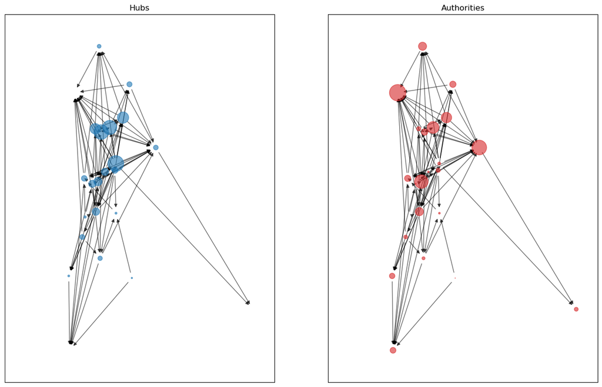

```python
fig, ax = plt.subplots(nrows=1, ncols=2, figsize=(16,10))
results = nx.pagerank(g_gc)
cmap = plt.get_cmap("RdYlGn")
g_gc_labels = dict(g_gc.nodes.data("name"))
plt.figure(figsize=(16,16))
pos = nx.spring_layout(g_gc, seed=42, k=0.5)
nx.draw_networkx_nodes(g_gc, pos=pos, node_size=[x*3000 for x in hubs], alpha=0.6, node_color="tab:blue", ax=ax[0])
nx.draw_networkx_edges(g_gc, pos=pos, alpha=0.6, ax=ax[0]);
ax[0].set_title("Hubs")

nx.draw_networkx_nodes(g_gc, pos=pos, node_size=[x*3000 for x in authorities], alpha=0.6, node_color="tab:red", ax=ax[1])
nx.draw_networkx_edges(g_gc, pos=pos, alpha=0.6, ax=ax[1]);
ax[1].set_title("Authorities");
```

## Community Detection

### Louvain Communities

Louvain communities is a graph algorithm that identifies clusters in the graph using the network itself. It is based on the modularity score. The math here is somewhat complicated but can be seen in the textbook.

What Louvain does is to iteratively partition the network into subparts by joining nodes together, and keeps doing this while the modularity score remains positive.

Louvain is a random process to some extent, so what you get may vary. Here unmodified it detects 4 communities, the friends of the President, the friends of the Instructor, and two "straggler" communities.

```python
results = nx.algorithms.community.louvain_communities(g_karate, seed=123)
len(results)
```

```
4
```

```python
comm0 = list(results[0])
comm1 = list(results[1])
comm2 = list(results[2])
comm3 = list(results[3])
```

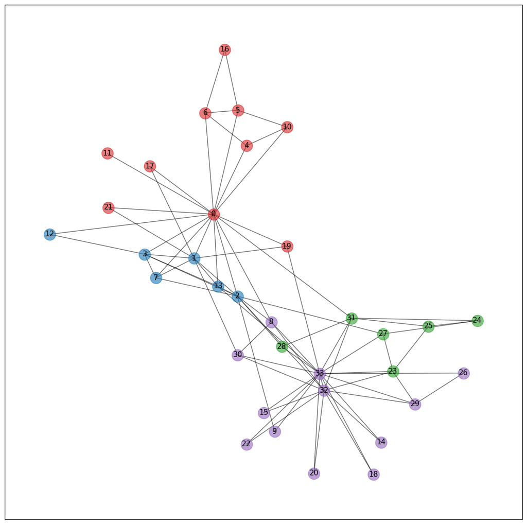

```python
pos = nx.spring_layout(g_karate, seed=42)
plt.figure(figsize=(14,14))
nx.draw_networkx_nodes(g_karate, pos=pos, nodelist=comm0, node_color="tab:blue", alpha=0.6)
nx.draw_networkx_nodes(g_karate, pos=pos, nodelist=comm1, node_color="tab:red", alpha=0.6)
nx.draw_networkx_nodes(g_karate, pos=pos, nodelist=comm2, node_color="tab:green", alpha=0.6)
nx.draw_networkx_nodes(g_karate, pos=pos, nodelist=comm3, node_color="tab:purple", alpha=0.6)
nx.draw_networkx_edges(g_karate, pos=pos, alpha=0.6)
nx.draw_networkx_labels(g_karate, pos=pos, font_size=11);
```

### Network Embeddings

Network embeddings uses machine learning techniques to reduce the network to a columnar representation (just like word vectors)

```python
n2v = karateclub.node2vec.Node2Vec(dimensions=3)

n2v.fit(g_karate)

X = n2v.get_embedding()
X
```

```
array([[-0.32790962,  1.0268639 ,  1.3969705 ],
       [ 0.20066027,  1.2040128 ,  0.8671412 ],
       [ 0.21912569,  1.2163862 ,  0.44904017],
       [-0.43132356,  1.0732437 ,  1.1499493 ],
       [-1.0779023 ,  1.4411186 ,  2.296233  ],
       [-0.72656226,  1.1654081 ,  2.9022546 ],
       [-1.0600089 ,  1.2197835 ,  2.7021382 ],
       [-0.00758829,  0.9006154 ,  1.1439465 ],
       [ 0.66546863,  1.2498853 , -0.71190536],
       [ 0.42045146,  1.4089421 , -0.4186437 ],
       [-1.039109  ,  1.5660596 ,  3.1978636 ],
       [-1.8269435 ,  2.6348276 ,  1.5516052 ],
       [-0.03583399,  1.0124491 ,  1.6559079 ],
       [ 0.2480749 ,  0.90889364,  1.0118922 ],
       [ 0.48867592,  1.7554442 , -0.8195491 ],
       [ 0.76181227,  1.5845641 , -1.7407314 ],
       [-0.8112537 ,  1.0840324 ,  2.735363  ],
       [-0.14060688,  1.3796811 ,  1.3241515 ],
       [ 0.8061459 ,  1.6256337 , -1.515557  ],
       [ 0.0060212 ,  0.9269446 ,  1.0697393 ],
       [ 1.1668204 ,  1.6684806 , -1.6997902 ],
       [-0.23490661,  1.0528299 ,  1.1764351 ],
       [ 1.0958852 ,  1.6141517 , -1.5660224 ],
       [ 2.5332677 ,  0.9458974 , -0.8418854 ],
       [ 3.6705894 ,  0.24531595,  0.5171788 ],
       [ 3.5694926 ,  0.5572675 ,  0.6031316 ],
       [ 1.3687788 ,  2.0356395 , -1.65612   ],
       [ 1.993427  ,  0.51182544,  0.03056931],
       [ 0.8983472 ,  1.1022222 ,  0.01994247],
       [ 1.8164741 ,  1.5567498 , -0.677992  ],
       [ 0.8937797 ,  1.3433677 , -0.66484946],
       [ 1.8857813 ,  0.8430052 ,  0.48456082],
       [ 0.88347304,  1.9574213 , -1.8265325 ],
       [ 1.164224  ,  1.9651713 , -0.8901427 ]], dtype=float32)
```

These can be used with traditional machine learning methods like KMeans to produce a clustering. KMeans requires that we know how many clusters we need, here this is an advantage, for we know th karate club split in two.

```python
km = KMeans(n_clusters=2)
km.fit(X)
predictions = km.predict(X)
```

```python
predictions
```

```
array([1, 1, 1, 1, 1, 1, 1, 1, 0, 0, 1, 1, 1, 1, 0, 0, 1, 1, 0, 1, 0, 1,
       0, 0, 0, 0, 0, 0, 0, 0, 0, 0, 0, 0], dtype=int32)
```

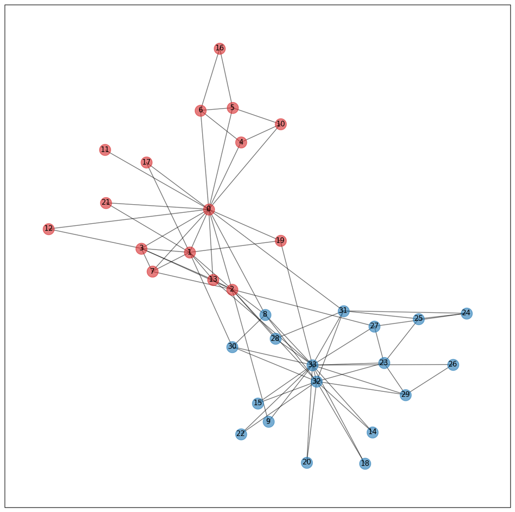

```python
g_karate = nx.karate_club_graph()
pos = nx.spring_layout(g_karate, seed=42)
plt.figure(figsize=(14,14))
nx.draw_networkx_nodes(g_karate, pos=pos, nodelist=[x for x,y in zip(list(g_karate.nodes), predictions) if y ==0], node_color="tab:blue", alpha=0.6)
nx.draw_networkx_nodes(g_karate, pos=pos, nodelist=[x for x,y in zip(list(g_karate.nodes), predictions) if y ==1], node_color="tab:red", alpha=0.6)
nx.draw_networkx_edges(g_karate, pos=pos, alpha=0.6)
nx.draw_networkx_labels(g_karate, pos=pos, font_size=11);
```

Network embeddings go back to the generality point made earlier. Networks are just one more data type that can be integrated into research.

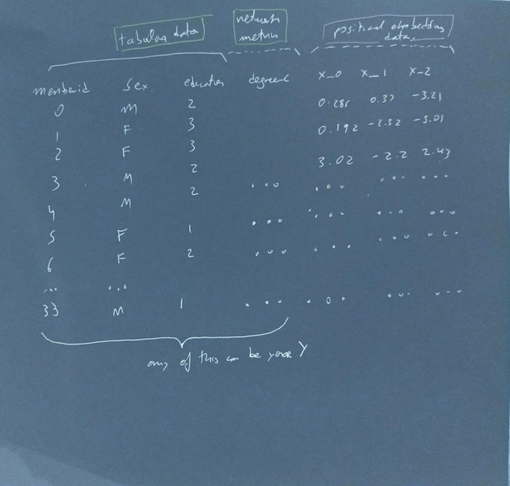

```python
Image(data="img/expanded_karate.jpeg")
```